# Tugas MPDW R3

# 5 Model Autoregressive

Pemodelan Autoregressive membutuhkan dua parameter yaitu p dan q sesuai dengan kondisi data. Agar dihasilkan model yang lebih sesuai, maka dapat langsung menggunakan nilai yang optimum.

## 5.1 *Lag* Optimum

```r
model.ardl.opt <- ardlBoundOrders(data = data.frame(data), ic = "AIC",
                                  formula = pm25 ~ AQI )
min_p=c()
for(i in 1:15){
  min_p[i]=min(model.ardl.opt$Stat.table[[i]])
}

q_opt=which(min_p==min(min_p, na.rm = TRUE))
p_opt=which(model.ardl.opt$Stat.table[[q_opt]] ==
              min(model.ardl.opt$Stat.table[[q_opt]], na.rm = TRUE))
data.frame("q_optimum" = q_opt, "p_optimum" = p_opt,
           "AIC"=model.ardl.opt$min.Stat)
```

```
##   q_optimum p_optimum       AIC
## 1         8         1 -203.1478
```

Dari tabel di atas, dapat terlihat bahwa nilai AIC terendah didapat ketika $p=1$ dan $q=8$, yaitu sebesar `-203.1478`. Artinya, model autoregressive optimum didapat ketika $p=1$ dan $q=8$.

## 5.2 Pemodelan

```r
model.ardl <- ardlDlm(formula = pm25 ~ AQI,
                         data = train,p = 15 , q = 12)
summary(model.ardl)
```

```
##
## Time series regression with "ts" data:
## Start = 16, End = 56
##
## Call:
## dynlm(formula = as.formula(model.text), data = data)
##
## Residuals:
##        Min         1Q     Median         3Q        Max
## -0.0271259 -0.0107642 -0.0003599  0.0120971  0.0312603
##
## Coefficients:
##               Estimate Std. Error t value Pr(>|t|)
## (Intercept)  0.6888931  1.1757219   0.586 0.568778
## AQI.t       -0.0285676  0.0138703  -2.060 0.061812 .
## AQI.1       -0.0048737  0.0147551  -0.330 0.746862
## AQI.2        0.0215632  0.0166914   1.292 0.220728
## AQI.3        0.0145076  0.0162229   0.894 0.388764
## AQI.4       -0.0007878  0.0148284  -0.053 0.958505
## AQI.5       -0.0047901  0.0137045  -0.350 0.732750
## AQI.6       -0.0210863  0.0151486  -1.392 0.189195
## AQI.7        0.0049726  0.0135420   0.367 0.719865
## AQI.8        0.0145321  0.0135908   1.069 0.305988
## AQI.9       -0.0100085  0.0132738  -0.754 0.465384
## AQI.10      -0.0032154  0.0150472  -0.214 0.834380
## AQI.11       0.0041725  0.0156252   0.267 0.793974
## AQI.12      -0.0026879  0.0157366  -0.171 0.867223
## AQI.13       0.0073883  0.0175811   0.420 0.681736
## AQI.14       0.0100373  0.0167316   0.600 0.559731
## AQI.15      -0.0167082  0.0126578  -1.320 0.211462
## pm25.1       1.3178345  0.2652519   4.968 0.000326 ***
## pm25.2      -0.5468875  0.4509259  -1.213 0.248538
## pm25.3       0.2463772  0.4641641   0.531 0.605244
## pm25.4       0.0726126  0.5385867   0.135 0.894989
## pm25.5      -0.3565097  0.5069450  -0.703 0.495318
## pm25.6       0.5280072  0.4533731   1.165 0.266804
## pm25.7      -0.5572407  0.4184923  -1.332 0.207751
## pm25.8       0.2790252  0.4066178   0.686 0.505624
## pm25.9      -0.0067649  0.3546518  -0.019 0.985095
## pm25.10     -0.3979969  0.3466682  -1.148 0.273315
## pm25.11      0.5853704  0.3004013   1.949 0.075107 .
## pm25.12     -0.2917445  0.1631368  -1.788 0.098977 .
## ---
## Signif. codes:  0 '***' 0.001 '**' 0.01 '*' 0.05 '.' 0.1 ' ' 1
##
## Residual standard error: 0.02839 on 12 degrees of freedom
## Multiple R-squared:  0.9962, Adjusted R-squared:  0.9873
## F-statistic: 112.3 on 28 and 12 DF,  p-value: 7.862e-11
```

```r
AIC(model.ardl)
```

```
## [1] -166.0807
```

```r
BIC(model.ardl)
```

```
## [1] -114.6735
```

Hasil model menunjukkan tidak semua peubah signifikan terhadap Y, hanya pm25.1 yang signifikan dengan nilai p kurang dari 0.05. Model keseluruhannya adalah sebagai berikut:

$$\hat{Y}=0.688-0.028X_t-0.004X_{t-1}-...+1.317Y_{t-1}+...-0.291Y_{t-12}$$

## 5.3 Peramalan dan Akurasi

```r
fore.ardl <- forecast(model = model.ardl, x=test$AQI, h=15)
fore.ardl
```

```
## $forecasts
##  [1] 2.168317 2.242379 2.316091 2.449684 2.551544 2.652294 2.766191 2.797319
##  [9] 2.772354 2.804237 2.864261 2.906620 2.880665 2.709333 2.524736
##
## $call
## forecast.ardlDlm(model = model.ardl, x = test$AQI, h = 15)
##
## attr(,"class")
## [1] "forecast.ardlDlm" "dLagM"
```

```r
# MAPE data uji
mape.ardl <- MAPE(fore.ardl$forecasts, test$pm25)
mape.ardl
```

```
## [1] 0.08477251
```

```r
# Akurasi data latih
GoF(model.ardl)
```

```
##             n        MAE           MPE        MAPE       sMAPE     MASE
## model.ardl 41 0.01316125 -6.084555e-05 0.006544986 0.006543839 0.374656
##                     MSE     MRAE     GMRAE
## model.ardl 0.0002359147 1.094079 0.4977993
```

# 6 Perbandingan Model

```r
akurasi <- matrix(c(mape.koyck, mape.dlm, mape.ardl))
row.names(akurasi)<- c("Koyck","DLM","Autoregressive")
colnames(akurasi) <- c("MAPE")
akurasi
```

```
##                      MAPE
## Koyck          0.13144119
## DLM            0.25246703
## Autoregressive 0.08477251
```

Berdasarkan nilai MAPE, model paling optimum didapat pada Model Autoregressive karena memiliki nilai MAPE yang terkecil.

## 6.1 Plot

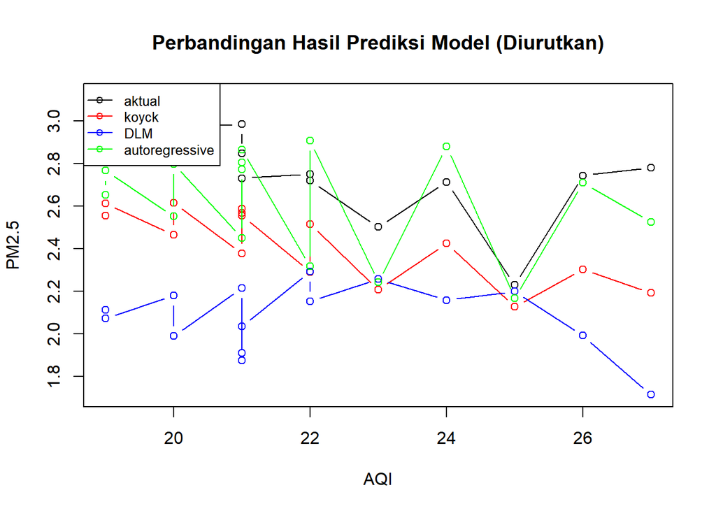

```r
sorted_order <- order(test$AQI)

sorted_aqi <- test$AQI[sorted_order]
sorted_pm25_aktual <- test$pm25[sorted_order]
sorted_koyck <- fore.koyck$forecasts[sorted_order]
sorted_dlm <- fore.dlm$forecasts[sorted_order]
sorted_ardl <- fore.ardl$forecasts[sorted_order]

y_range <- range(c(sorted_pm25_aktual, sorted_koyck, sorted_dlm, sorted_ardl), na.rm = TRUE)

plot(sorted_aqi, sorted_pm25_aktual, type = "b", col = "black", ylim = y_range,
     xlab = "AQI", ylab = "PM2.5", main = "Perbandingan Hasil Prediksi Model (Diurutkan)")

lines(sorted_aqi, sorted_koyck, type = "b", col = "red")
lines(sorted_aqi, sorted_dlm, type = "b", col = "blue")
lines(sorted_aqi, sorted_ardl, type = "b", col = "green")

legend("topleft", legend = c("aktual", "koyck", "DLM", "autoregressive"),
       col = c("black", "red", "blue", "green"), lty = 1, pch = 1, cex = 0.8)
```

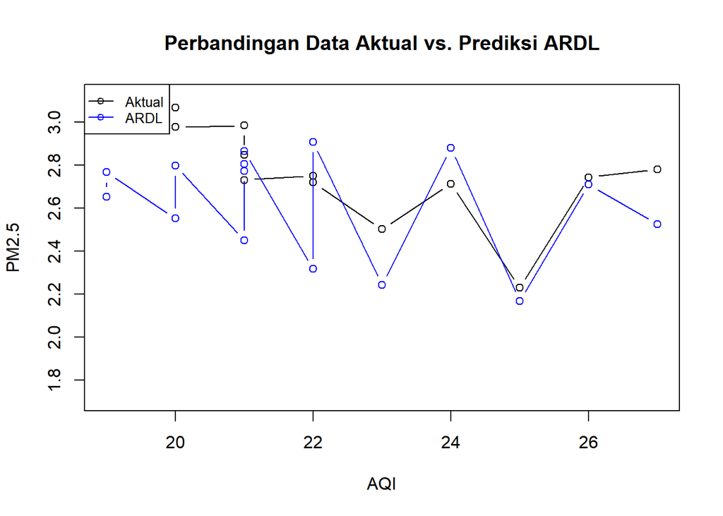

```r
plot(sorted_aqi, sorted_pm25_aktual, type = "b", col = "black", ylim = y_range,
     xlab = "AQI", ylab = "PM2.5", main = "Perbandingan Data Aktual vs. Prediksi ARDL")

lines(sorted_aqi, sorted_ardl, type = "b", col = "blue")

legend("topleft", legend = c("Aktual", "ARDL"),
       col = c("black", "blue"), lty = 1, pch = 1, cex = 0.8)
```

# 7 Uji Asumsi

## 7.1 SSE

```r
deviance(model.dlm$model)
```

```
## [1] 0.0005356284
```

## 7.2 Autokorelasi

```r
dwtest(model.dlm$model)
```

```
##
##  Durbin-Watson test
##
## data:  model.dlm$model
## DW = 2.6167, p-value = 0.5742
## alternative hypothesis: true autocorrelation is greater than 0
```

## 7.3 Heterogenitas

```r
bptest(model.dlm$model)
```

```
##
##  studentized Breusch-Pagan test
##
## data:  model.dlm$model
## BP = 26.547, df = 27, p-value = 0.4884
```

## 7.4 Kenormalan

```r
shapiro.test(residuals(model.dlm$model))
```

```
##
##  Shapiro-Wilk normality test
##
## data:  residuals(model.dlm$model)
## W = 0.96277, p-value = 0.3639
```